# R Notebook

Logistic Regression Project

In this project we will be working with the UCI adult dataset. We will be attempting to predict if people in the data set belong in a certain class by salary, either making <=50k or >50k per year.

Typically most of your time is spent cleaning data, not running the few lines of code that build your model, this project will try to reflect that by showing different issues that may arise when cleaning data.

Get the Data

Read in the adult_sal.csv file and set it to a data frame called adult.

|  | X | age | type_employer | fnlwgt | education | education_num | marital | occupation | relationship | race | sex | capital_gain | capital_loss | hr_per_week | country | income |
| --- | --- | --- | --- | --- | --- | --- | --- | --- | --- | --- | --- | --- | --- | --- | --- | --- |
| 1 | 1 | 39 | State-gov | 77516 | Bachelors | 13 | Never-married | Adm-clerical | Not-in-family | White | Male | 2174 | 0 | 40 | United-States | <=50K |
| 2 | 2 | 50 | Self-emp-not-inc | 83311 | Bachelors | 13 | Married-civ-spouse | Exec-managerial | Husband | White | Male | 0 | 0 | 13 | United-States | <=50K |
| 3 | 3 | 38 | Private | 215646 | HS-grad | 9 | Divorced | Handlers-cleaners | Not-in-family | White | Male | 0 | 0 | 40 | United-States | <=50K |
| 4 | 4 | 53 | Private | 234721 | 11th | 7 | Married-civ-spouse | Handlers-cleaners | Husband | Black | Male | 0 | 0 | 40 | United-States | <=50K |
| 5 | 5 | 28 | Private | 338409 | Bachelors | 13 | Married-civ-spouse | Prof-specialty | Wife | Black | Female | 0 | 0 | 40 | Cuba | <=50K |
| 6 | 6 | 37 | Private | 284582 | Masters | 14 | Married-civ-spouse | Exec-managerial | Wife | White | Female | 0 | 0 | 40 | United-States | <=50K |

You should notice the index has been repeated. Drop this column.

```r
library(dplyr)
adult <- select(adult, -X)
head(adult)
```

|  | age | type_employer | fnlwgt | education | education_num | marital | occupation | relationship | race | sex | capital_gain | capital_loss | hr_per_week | country | income |
| --- | --- | --- | --- | --- | --- | --- | --- | --- | --- | --- | --- | --- | --- | --- | --- |
| 1 | 39 | State-gov | 77516 | Bachelors | 13 | Never-married | Adm-clerical | Not-in-family | White | Male | 2174 | 0 | 40 | United-States | <=50K |
| 2 | 50 | Self-emp-not-inc | 83311 | Bachelors | 13 | Married-civ-spouse | Exec-managerial | Husband | White | Male | 0 | 0 | 13 | United-States | <=50K |
| 3 | 38 | Private | 215646 | HS-grad | 9 | Divorced | Handlers-cleaners | Not-in-family | White | Male | 0 | 0 | 40 | United-States | <=50K |
| 4 | 53 | Private | 234721 | 11th | 7 | Married-civ-spouse | Handlers-cleaners | Husband | Black | Male | 0 | 0 | 40 | United-States | <=50K |
| 5 | 28 | Private | 338409 | Bachelors | 13 | Married-civ-spouse | Prof-specialty | Wife | Black | Female | 0 | 0 | 40 | Cuba | <=50K |
| 6 | 37 | Private | 284582 | Masters | 14 | Married-civ-spouse | Exec-managerial | Wife | White | Female | 0 | 0 | 40 | United-States | <=50K |

```r
str(adult)
```

```
'data.frame':   32561 obs. of  15 variables:
 $ age          : int  39 50 38 53 28 37 49 52 31 42 ...
 $ type_employer: Factor w/ 9 levels "?","Federal-gov",..: 8 7 5 5 5 5 5 7 5 5 ...
 $ fnlwgt       : int  77516 83311 215646 234721 338409 284582 160187 209642 45781 159449 ...
 $ education    : Factor w/ 16 levels "10th","11th",..: 10 10 12 2 10 13 7 12 13 10 ...
 $ education_num: int  13 13 9 7 13 14 5 9 14 13 ...
 $ marital      : Factor w/ 7 levels "Divorced","Married-AF-spouse",..: 5 3 1 3 3 3 4 3 5 3 ...
 $ occupation   : Factor w/ 15 levels "?","Adm-clerical",..: 2 5 7 7 11 5 9 5 11 5 ...
 $ relationship : Factor w/ 6 levels "Husband","Not-in-family",..: 2 1 2 1 6 6 2 1 2 1 ...
 $ race         : Factor w/ 5 levels "Amer-Indian-Eskimo",..: 5 5 5 3 3 5 3 5 5 5 ...
 $ sex          : Factor w/ 2 levels "Female","Male": 2 2 2 2 1 1 1 2 1 2 ...
 $ capital_gain : int  2174 0 0 0 0 0 0 0 14084 5178 ...
 $ capital_loss : int  0 0 0 0 0 0 0 0 0 0 ...
 $ hr_per_week  : int  40 13 40 40 40 40 16 45 50 40 ...
 $ country      : Factor w/ 42 levels "?","Cambodia",..: 40 40 40 40 6 40 24 40 40 40 ...
 $ income       : Factor w/ 2 levels "<=50K",">50K": 1 1 1 1 1 1 1 2 2 2 ...
```

```r
summary(adult)
```

```
      age                 type_employer       fnlwgt               education     education_num
 Min.   :17.00   Private         :22696   Min.   :  12285   HS-grad     :10501   Min.   : 1.00
 1st Qu.:28.00   Self-emp-not-inc: 2541   1st Qu.: 117827   Some-college: 7291   1st Qu.: 9.00
 Median :37.00   Local-gov       : 2093   Median : 178356   Bachelors   : 5355   Median :10.00
 Mean   :38.58   ?               : 1836   Mean   : 189778   Masters     : 1723   Mean   :10.08
 3rd Qu.:48.00   State-gov       : 1298   3rd Qu.: 237051   Assoc-voc   : 1382   3rd Qu.:12.00
 Max.   :90.00   Self-emp-inc    : 1116   Max.   :1484705   11th        : 1175   Max.   :16.00
                 (Other)         :  981                     (Other)     : 5134
                  marital                occupation           relationship                   race
 Divorced             : 4443   Prof-specialty :4140   Husband       :13193   Amer-Indian-Eskimo:  311
 Married-AF-spouse    :   23   Craft-repair   :4099   Not-in-family : 8305   Asian-Pac-Islander: 1039
 Married-civ-spouse   :14976   Exec-managerial:4066   Other-relative:  981   Black             : 3124
 Married-spouse-absent:  418   Adm-clerical   :3770   Own-child     : 5068   Other             :  271
 Never-married        :10683   Sales          :3650   Unmarried     : 3446   White             :27816
 Separated            : 1025   Other-service  :3295   Wife          : 1568
 Widowed              :  993   (Other)        :9541
     sex         capital_gain    capital_loss     hr_per_week             country        income
 Female:10771   Min.   :    0   Min.   :   0.0   Min.   : 1.00   United-States:29170   <=50K:24720
 Male  :21790   1st Qu.:    0   1st Qu.:   0.0   1st Qu.:40.00   Mexico       :  643   >50K : 7841
                Median :    0   Median :   0.0   Median :40.00   ?            :  583
                Mean   : 1078   Mean   :  87.3   Mean   :40.44   Philippines  :  198
                3rd Qu.:    0   3rd Qu.:   0.0   3rd Qu.:45.00   Germany      :  137
                Max.   :99999   Max.   :4356.0   Max.   :99.00   Canada       :  121
                                                                 (Other)      : 1709
```

Data Cleaning

Notice that we have a lot of columns that are cateogrical factors, however a lot of these columns have too many factors than may be necessary. In this data cleaning section we’ll try to clean these columns up by reducing the number of factors.

type_employer column

Use table() to check out the frequency of the type_employer column.

```r
table(adult$type_employer)
```

```
               ?      Federal-gov        Local-gov     Never-worked          Private     Self-emp-inc
            1836              960             2093                7            22696             1116
Self-emp-not-inc        State-gov      Without-pay
            2541             1298               14
```

```r
any(is.na(adult$type_employer))
```

```
[1] FALSE
```

Combine these two smallest groups into a single group called “Unemployed”. There are lots of ways to do this, so feel free to get creative. Hint: It may be helpful to convert these objects into character data types (as.character() and then use sapply with a custom function)

```r
unempl <- function(job){
  job <- as.character(job)
  if(job == 'Never-worked' | job == 'Without-pay'){
    return('Unemployed')
  }else{
    return(job)
  }
}
adult$type_employer <- sapply(adult$type_employer, unempl)
print(table(adult$type_employer))
```

```
               ?      Federal-gov        Local-gov          Private     Self-emp-inc Self-emp-not-inc
            1836              960             2093            22696             1116             2541
       State-gov       Unemployed
            1298               21
```

What other columns are suitable for combining? Combine State and Local gov jobs into a category called SL-gov and combine self-employed jobs into a category called self-emp. Group Self Employed and state And local

```r
group_emp <- function(job){
  job = as.character(job)
  if(job == 'Local-gov' | job == 'State-gov'){
    return('SL-gov')
  }else if(job == 'Self-emp-inc' | job == 'Self-emp-not-inc'){
    return('Self-emp')
  }else{
return(job)
  }
}
adult$type_employer <- sapply(adult$type_employer, group_emp)
table(adult$type_employer)
```

```
          ? Federal-gov     Private    Self-emp      SL-gov  Unemployed
       1836         960       22696        3657        3391          21
```

Marital Column Group marital column –> married, never married, not married

```r
table(adult$marital)
```

```
             Divorced     Married-AF-spouse    Married-civ-spouse Married-spouse-absent         Never-married
                 4443                    23                 14976                   418                 10683
            Separated               Widowed
                 1025                   993
```

```r
marital <- function(status){
  status = as.character(status)
  if(status == 'Divorced' | status == 'Separated' | status =='Widowed'){
    return('Not-Married')
  }else if(status == 'Never-married'){
    return(status)
  }else{
    return('Married')
  }
}

adult$marital <- sapply(adult$marital, marital)
table(adult$marital)
```

```
      Married Never-married   Not-Married
        15417         10683          6461
```

Country Column

Check the country column using table()

```r
table(adult$country)
```

```
                         ?                   Cambodia                     Canada                      China
                       583                         19                        121                         75
                  Columbia                       Cuba         Dominican-Republic                    Ecuador
                        59                         95                         70                         28
               El-Salvador                    England                     France                    Germany
                       106                         90                         29                        137
                    Greece                  Guatemala                      Haiti         Holand-Netherlands
                        29                         64                         44                          1
                  Honduras                       Hong                    Hungary                      India
                        13                         20                         13                        100
                      Iran                    Ireland                      Italy                    Jamaica
                        43                         24                         73                         81
                     Japan                       Laos                     Mexico                  Nicaragua
                        62                         18                        643                         34
Outlying-US(Guam-USVI-etc)                       Peru                Philippines                     Poland
                        14                         31                        198                         60
                  Portugal                Puerto-Rico                   Scotland                      South
                        37                        114                         12                         80
                    Taiwan                   Thailand            Trinadad&Tobago              United-States
                        51                         18                         19                      29170
                   Vietnam                 Yugoslavia
                        67                         16
```

Group these countries together however you see fit. You have flexibility here because there is no right/wrong way to do this, possibly group by continents. You should be able to reduce the number of groups here significantly though.

```r
areas <- function(country){
  country = as.character(country)
  if(country =='United-States'| country == 'Puerto-Rico'|country=='Mexico'|country == 'Canada' | country == 'Columbia' | country == 'Cuba'| country == 'Cambodia'| country ==  'Ecuador'| country=='El-Salvador'){
    return('America')

  }

  if(country =='China'| country == 'Hong'| country == 'Hungary'| country == 'India'| country == 'Iran'| country == 'Ireland'| country == 'Japan' | country =='Taiwan'| country == 'Thailand'){
    return('Asia')

  }

  if(country == 'England'|country =='France'| country == 'Germany'| country =='Greece'| country =='Holand-Netherlands'| country =='Italy'| country =='Philippines'| country == 'Poland'| country == 'Portugal'| country == 'Puerto-Rico'| country == 'Scotland'  | country =='Vietnam'){
    return('Europe')

  }

  else{
    return("Others")
  }
}
adult$country <- sapply(adult$country, areas)
table(adult$country)
```

```
America    Asia  Europe  Others
  30355     406     733    1067
```

Check the str() of adult again. Make sure any of the columns we changed have factor levels with factor()

```r
str(adult)
```

```
'data.frame':   32561 obs. of  15 variables:
 $ age          : int  39 50 38 53 28 37 49 52 31 42 ...
 $ type_employer: chr  "SL-gov" "Self-emp" "Private" "Private" ...
 $ fnlwgt       : int  77516 83311 215646 234721 338409 284582 160187 209642 45781 159449 ...
 $ education    : Factor w/ 16 levels "10th","11th",..: 10 10 12 2 10 13 7 12 13 10 ...
 $ education_num: int  13 13 9 7 13 14 5 9 14 13 ...
 $ marital      : chr  "Never-married" "Married" "Not-Married" "Married" ...
 $ occupation   : Factor w/ 15 levels "?","Adm-clerical",..: 2 5 7 7 11 5 9 5 11 5 ...
 $ relationship : Factor w/ 6 levels "Husband","Not-in-family",..: 2 1 2 1 6 6 2 1 2 1 ...
 $ race         : Factor w/ 5 levels "Amer-Indian-Eskimo",..: 5 5 5 3 3 5 3 5 5 5 ...
 $ sex          : Factor w/ 2 levels "Female","Male": 2 2 2 2 1 1 1 2 1 2 ...
 $ capital_gain : int  2174 0 0 0 0 0 0 0 14084 5178 ...
 $ capital_loss : int  0 0 0 0 0 0 0 0 0 0 ...
 $ hr_per_week  : int  40 13 40 40 40 40 16 45 50 40 ...
 $ country      : chr  "America" "America" "America" "America" ...
 $ income       : Factor w/ 2 levels "<=50K",">50K": 1 1 1 1 1 1 1 2 2 2 ...
```

```r
adult$type_employer <- sapply(adult$type_employer, factor)
adult$country <- sapply(adult$country, factor)
adult$marital <- sapply(adult$marital, factor)
```

Missing Data

Notice how we have data that is missing.

```r
library(Amelia)
# convert all '?' to NA values
adult[adult == '?'] <- NA
print(table(adult$type_employer))
```

```
     SL-gov    Self-emp     Private Federal-gov           ?  Unemployed
       3391        3657       22696         960           0          21
```

```r
#removing '?' factor
adult$type_employer <- sapply(adult$type_employer, factor)
adult$country <- sapply(adult$country, factor)
adult$marital <- sapply(adult$marital, factor)
print(table(adult$type_employer))
```

```
     SL-gov    Self-emp     Private Federal-gov  Unemployed
       3391        3657       22696         960          21
```

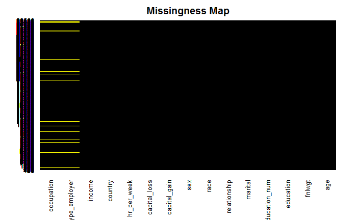

```r
missmap(adult, legend = F, col = c('yellow' , 'black'))
```

As the missing data is from occupation and type_employees which are non numeric data so we cannot take the average of it. The missing data is less so we can omit that data from adult dataset itself.

Drop missing data

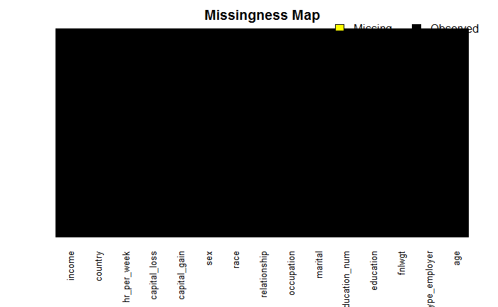

EDA

Although we’ve cleaned the data, we still have explored it using visualization.

Check the str() of the data.

```r
str(adult)
```

```
'data.frame':   30718 obs. of  15 variables:
 $ age          : int  39 50 38 53 28 37 49 52 31 42 ...
 $ type_employer: Factor w/ 5 levels "SL-gov","Self-emp",..: 1 2 3 3 3 3 3 2 3 3 ...
 $ fnlwgt       : int  77516 83311 215646 234721 338409 284582 160187 209642 45781 159449 ...
 $ education    : Factor w/ 16 levels "10th","11th",..: 10 10 12 2 10 13 7 12 13 10 ...
 $ education_num: int  13 13 9 7 13 14 5 9 14 13 ...
 $ marital      : Factor w/ 3 levels "Never-married",..: 1 2 3 2 2 2 2 2 1 2 ...
 $ occupation   : Factor w/ 15 levels "?","Adm-clerical",..: 2 5 7 7 11 5 9 5 11 5 ...
 $ relationship : Factor w/ 6 levels "Husband","Not-in-family",..: 2 1 2 1 6 6 2 1 2 1 ...
 $ race         : Factor w/ 5 levels "Amer-Indian-Eskimo",..: 5 5 5 3 3 5 3 5 5 5 ...
 $ sex          : Factor w/ 2 levels "Female","Male": 2 2 2 2 1 1 1 2 1 2 ...
 $ capital_gain : int  2174 0 0 0 0 0 0 0 14084 5178 ...
 $ capital_loss : int  0 0 0 0 0 0 0 0 0 0 ...
 $ hr_per_week  : int  40 13 40 40 40 40 16 45 50 40 ...
 $ country      : Factor w/ 4 levels "America","Others",..: 1 1 1 1 1 1 2 1 1 1 ...
 $ income       : Factor w/ 2 levels "<=50K",">50K": 1 1 1 1 1 1 1 2 2 2 ...
 - attr(*, "na.action")=Class 'omit'  Named int [1:1843] 28 62 70 78 107 129 150 155 161 188 ...
  .. ..- attr(*, "names")= chr [1:1843] "28" "62" "70" "78" ...
```

Use ggplot2 to create a histogram of ages, colored by income.

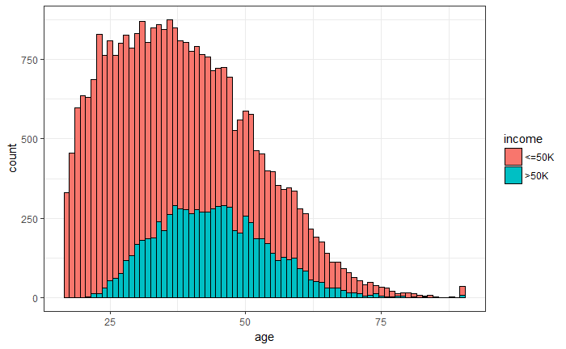

Plot a histogram of hours worked per week

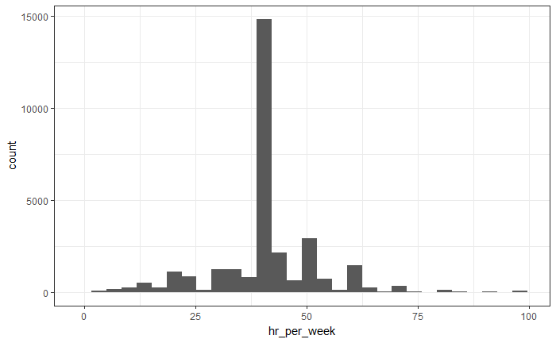

```r
ggplot(adult, aes(hr_per_week)) + geom_histogram() + theme_bw()
```

Rename the country column to region column to better reflect the factor levels.

```r
adult <- rename(adult, region = country)
head(adult, 3)
```

|  | age | type_employer | fnlwgt | education | education_num | marital | occupation | relationship | race | sex | capital_gain | capital_loss | hr_per_week | region | income |
| --- | --- | --- | --- | --- | --- | --- | --- | --- | --- | --- | --- | --- | --- | --- | --- |
| 1 | 39 | SL-gov | 77516 | Bachelors | 13 | Never-married | Adm-clerical | Not-in-family | White | Male | 2174 | 0 | 40 | America | <=50K |
| 2 | 50 | Self-emp | 83311 | Bachelors | 13 | Married | Exec-managerial | Husband | White | Male | 0 | 0 | 13 | America | <=50K |
| 3 | 38 | Private | 215646 | HS-grad | 9 | Not-Married | Handlers-cleaners | Not-in-family | White | Male | 0 | 0 | 40 | America | <=50K |

Create a barplot of region with the fill color defined by income class. Optional: Figure out how rotate the x axis text for readability

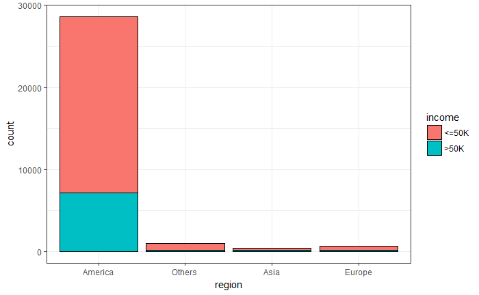

```r
ggplot(adult, aes(region)) + geom_bar(aes(fill=income), color = 'black') + theme_bw()
```

Building a Model

Now it’s time to build a model to classify people into two groups: Above or Below 50k in Salary.

Logistic Regression

Refer to the Lecture or ISLR if you are fuzzy on any of this.

Logistic Regression is a type of classification model. In classification models, we attempt to predict the outcome of categorical dependent variables, using one or more independent variables. The independent variables can be either categorical or numerical.

Logistic regression is based on the logistic function, which always takes values between 0 and 1. Replacing the dependent variable of the logistic function with a linear combination of dependent variables we intend to use for regression, we arrive at the formula for logistic regression.

Take a quick look at the head() of adult to make sure we have a good overview before going into building the model!

```r
head(adult)
```

|  | age | type_employer | fnlwgt | education | education_num | marital | occupation | relationship | race | sex | capital_gain | capital_loss | hr_per_week | region | income |
| --- | --- | --- | --- | --- | --- | --- | --- | --- | --- | --- | --- | --- | --- | --- | --- |
| 1 | 39 | SL-gov | 77516 | Bachelors | 13 | Never-married | Adm-clerical | Not-in-family | White | Male | 2174 | 0 | 40 | America | <=50K |
| 2 | 50 | Self-emp | 83311 | Bachelors | 13 | Married | Exec-managerial | Husband | White | Male | 0 | 0 | 13 | America | <=50K |
| 3 | 38 | Private | 215646 | HS-grad | 9 | Not-Married | Handlers-cleaners | Not-in-family | White | Male | 0 | 0 | 40 | America | <=50K |
| 4 | 53 | Private | 234721 | 11th | 7 | Married | Handlers-cleaners | Husband | Black | Male | 0 | 0 | 40 | America | <=50K |
| 5 | 28 | Private | 338409 | Bachelors | 13 | Married | Prof-specialty | Wife | Black | Female | 0 | 0 | 40 | America | <=50K |
| 6 | 37 | Private | 284582 | Masters | 14 | Married | Exec-managerial | Wife | White | Female | 0 | 0 | 40 | America | <=50K |

Train Test Split

Split the data into a train and test set using the caTools library as done in previous lectures. Reference previous solutions notebooks if you need a refresher.

```r
library(caTools)
sample <- sample.split(adult$income, SplitRatio = 0.70)
train.adult <- subset(adult, sample == T)
test.adult <- subset(adult, sample == F)
```

Training the Model